# A Shallow Dive into the Deep Pool of Amazon Review Data

4/30/2018

## Visualize the Dive

## NY Times API and UCSD Amazon Data

The Theory: A book listed on the NY Times Best Sellers list will have positive review sentiment

- The New York Times Best Seller list is widely considered the preeminent list of best-selling books in the United States.
- Amazon.com is recognized as the largest hub of book sales and offers thousands of user reviews per publication

The Plan:

-Conduct sentiment analysis on the Amazon reviews of the books most-frequently featured on the NYT Best Seller's list

## Don't dive if you can't see the bottom

## Flaws in design

Assumptions:

- The UCSD Amazon data is a collection of workable review data from 1996 - 2014
- I would access the NY Times Best Sellers History API and collect the data on these years

Reality:

- The UCSD Amazon data is contained in a 4GB JSON file, containing ~9 million reviews
- NY Times API only provides recent Best Seller Data

## Close your eyes and jump

## Make it work

Attempts:

- Scrape the NYT Best Seller wikipedia pages for 1996 - 2014
- Open the 4GB JSON file in terminal, use grep() to find reviews based on the book's unique Amazon ID

Result:

- The JSON file only contains a few, if any, reviews of the books I'm interested in
- The JSON data is very dirty; missing characters, titles, Amazon ID's

Realization: This is not a viable approach for this analysis

## Just Keep Swimming

## Try Smarter, Not Harder

Scrape the NYT Best Seller data:

- Who are the most frequent Authors?
- What are the most frequent Titles?

From there we can find which book reviews to analyze

## NYT Graph Analysis

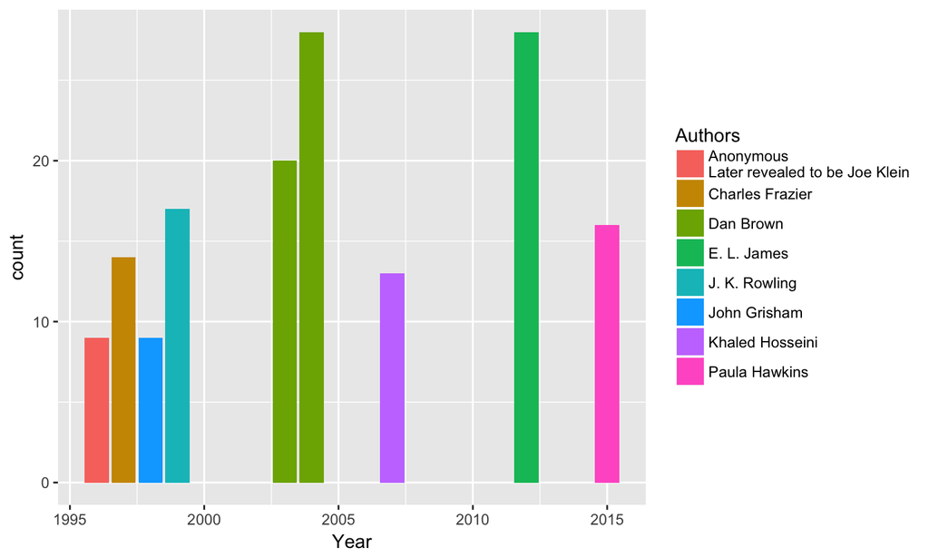

```
## $y
## [1] "Weeks"
##
## attr(,"class")
## [1] "labels"
```

## NYT Graph Analysis

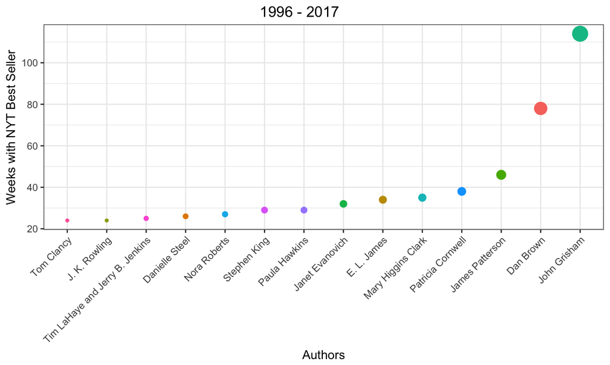

## NYT Graph Analysis

Most Frequent Best Seller Books 1996 - 2017

| Book | Author | Weeks |
| --- | --- | --- |
| The Da Vinci Code | Dan Brown | 59 |
| Fifty Shades of Grey | E. L. James | 29 |
| The Girl on the Train | Paula Hawkins | 26 |
| Cold Mountain | Charles Frazier | 18 |
| A Thousand Splendid Suns | Khaled Hosseini | 15 |
| Harry Potter and the Chamber of Secrets | J. K. Rowling | 12 |

## NYT Graph Analysis

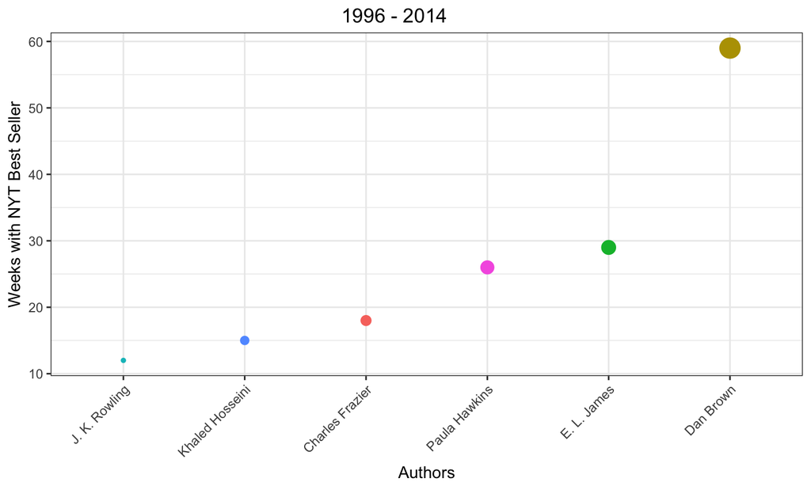

## Access Usable Amazon Review Data

Scrape the initial Amazon Reviews for the most frequent Titles:

- Tidy the data
- Conduct sentiment analysis

See if the sentiment complements the Best Seller Status

## Amazon Analysis

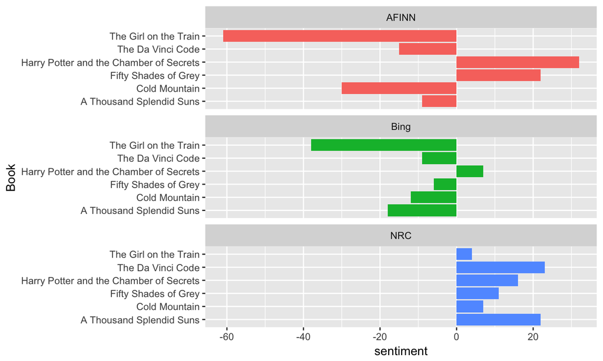

## Conclusions

## What do we think?

- This theory has not been proven
- Positive sentiment does not seem to be related to Best Seller reviews

What else could we do?

- Compare review sentiment to average Amazon Start score rating
- Scrape more reviews, analyze the sentiment over time
- Understand book reviews are subjective and difficult to analyze
- "This book was terrifying" could be considered a positive review for a thriller